# [과제11] 모집단이 두 개인 경우 (독립표본, 대응표본) + 모집단이 세 개인 경우 (ANOVA, 적합도/독립성 검정)

#### **비모수적 통계검정 (Wilcoxon rank test)**

##### 정규성 검정 결과 모두 p-value의 값이 유의수준 0.05보다 작아 정규성이 만족되지 않는다. 따라서 비모수검정방법 중 하나인 윌콕스 순위 검정을 시행한다.

```r
# H0 : mu1 == mu2
# H1 : mu1 != mu2

wilcox.test(mpg_sub_mid$hwy ~ mpg_sub_mid$class)
```

```
##
##  Wilcoxon rank sum test with continuity correction
##
## data:  mpg_sub_mid$hwy by mpg_sub_mid$class
## W = 719, p-value = 0.9916
## alternative hypothesis: true location shift is not equal to 0
```

```r
# 윌콕스 검정 결과 유의확률이 0.9916으로 귀무가설을 기각할 충분한 근거가 없다. 즉 subcompact자동차와 midsize 자동차의 고속도로 연비는 차이가 없다.
```

#### **모수적 통계검정 (2-sample T-test)**

##### 만약 두 집단의 가격이 모두 정규분포를 따른다고 가정한다면, 모수적 방법인 2-sample T-test를 사용한다.

```r
# 0. 등분산성 검정

var.test(mpg_sub_mid$hwy ~ mpg_sub_mid$class) # p = 0.0000 으로 등분산성을 만족하지 않으므로, 이분산 t-test를 진행한다.
```

```
##
##  F test to compare two variances
##
## data:  mpg_sub_mid$hwy by mpg_sub_mid$class
## F = 0.15791, num df = 40, denom df = 34, p-value = 8.825e-08
## alternative hypothesis: true ratio of variances is not equal to 1
## 95 percent confidence interval:
##  0.08116414 0.30185921
## sample estimates:
## ratio of variances
##          0.1579119
```

```r
# 1. 가설설정

# H0 : 자동차 종류(subcompact, midsize)에 따른 고속도로 연비가 차이가 없다
# H1 : 자동차 종류(subcompact, midsize)에 따른 고속도로 연비가 차이가 있다 (양측)

# 2. 판정

t.test(mpg_sub_mid$hwy ~ mpg_sub_mid$class, mu=0, alternative = "two.sided", var.equal=F) # 등분산성을 만족하지 않아 이분산을 가정한 t-test를 진행
```

```
##
##  Welch Two Sample t-test
##
## data:  mpg_sub_mid$hwy by mpg_sub_mid$class
## t = -0.87842, df = 43.118, p-value = 0.3846
## alternative hypothesis: true difference in means is not equal to 0
## 95 percent confidence interval:
##  -2.801864  1.101515
## sample estimates:
##    mean in group midsize mean in group subcompact
##                 27.29268                 28.14286
```

```r
mean(subcm$hwy); sd(subcm$hwy)  # 차량종류가 subcompact인 차량의 고속도로 평균 연비와 표준편차
```

```
## [1] 28.14286
```

```
## [1] 5.375012
```

```r
mean(mid$hwy); sd(mid$hwy)      # 차량종류가 mid인 차량의 고속도로 평균 연비와 표준편차
```

```
## [1] 27.29268
```

```
## [1] 2.13593
```

```r
# 3. 결론

# 차량종류(class)에 따라 고속도로 평균 연비가 차이가 있는지 알아보기 위해 76개의 자동차 표본을 추출해 분석한 결과,
# 차량종류가 subcompact인 차량의 고속도로 평균 연비와 표준편차는 28.14±+5.37,
# 차량종류가 midsize인 차량의 고속도로 평균 연비와 표준편차는 27.29±2.13으로 나타났다.
# 이를 유의수준 0.05에서 가설검정하면 검정통계량과 유의확률이 -0.8784(p=0.3846)으로 나타나
# 차량 종류에 따른 고속도로 평균 연비 차이가 통계적으로 유의하지 않다는 결론을 내릴 수 있다.
# 즉 차량 종류(subcompact, midsize)에 따른 고속도로 평균 연비(hwy)는 차이가 없다.
```

#### 3-2) 일반 휘발유(r)와 고급 휘발유(p)의 도시 연비간의 차이가 있는가?

```r
str(mpg$fl)
```

```
##  chr [1:234] "p" "p" "p" "p" "p" "p" "p" "p" "p" "p" "p" "p" "p" "p" ...
```

```
##
##  Shapiro-Wilk normality test
##
## data:  r$cty
## W = 0.9542, p-value = 2.7e-05
```

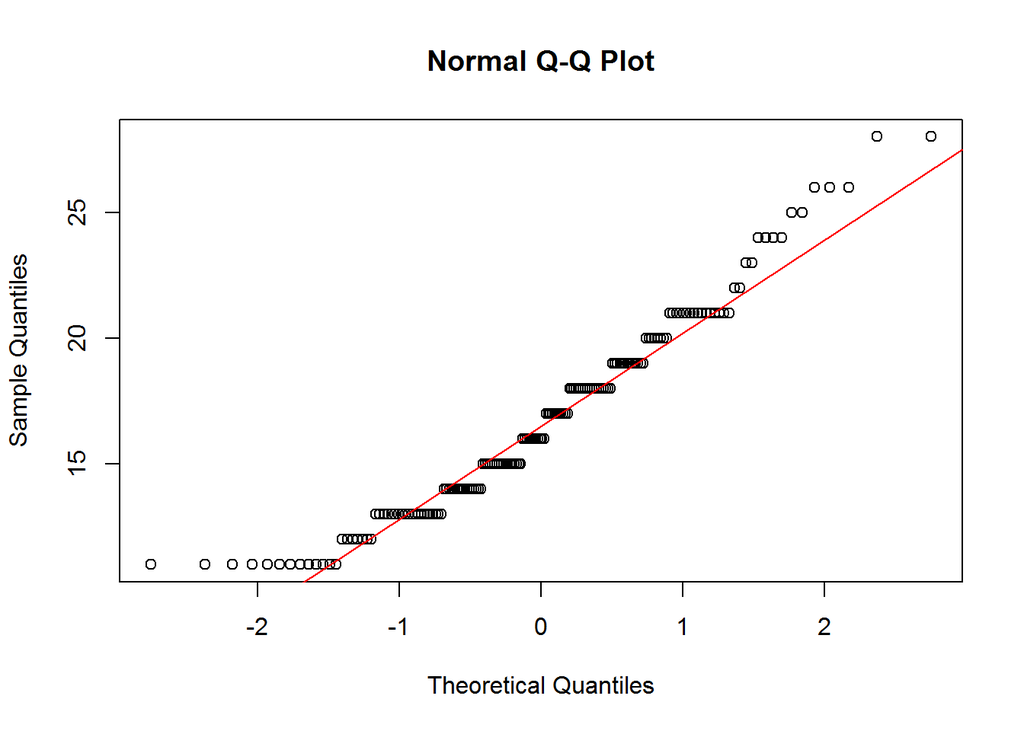

```r
# 0. 정규성 및 등분산성 검정

r <- dplyr::select(mpg, fl, cty) %>% filter(fl == "r")
p <- dplyr::select(mpg, fl, cty) %>% filter(fl == "p")

shapiro.test(r$cty); qqnorm(r$cty); qqline(r$cty, col="red")  # p = 0.000027로 정규성을 만족하지 않음
```

```
##
##  Shapiro-Wilk normality test
##
## data:  p$cty
## W = 0.95546, p-value = 0.04984
```

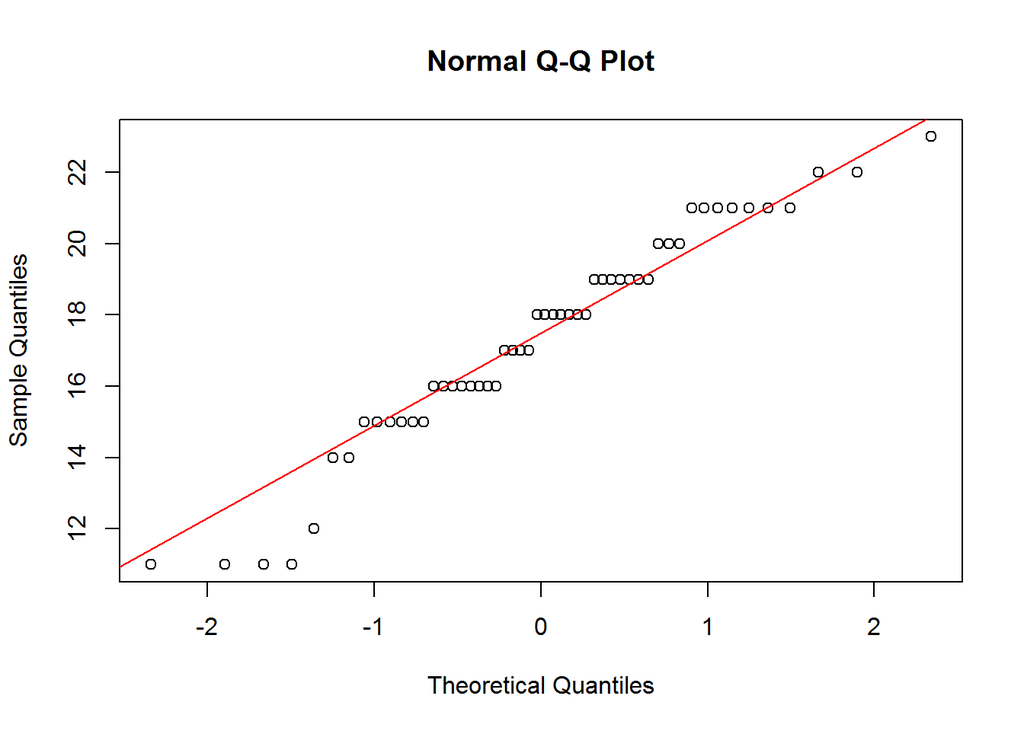

```r
shapiro.test(p$cty); qqnorm(p$cty); qqline(p$cty, col="red")  # p = 0.04984로 정규성을 근소하게 만족하지 않음
```

```r
mpg_r_p <- filter(mpg, fl %in% c("r","p"))  # fl(연료종류)가 r(일반휘발유)과 p(고급휘발유)인 데이터만 추출
```

#### **비모수적 통계검정 (Wilcoxon rank test)**

##### 정규성 검정 결과 모두 p-value의 값이 유의수준 0.05보다 작아 정규성이 만족되지 않는다. 따라서 비모수검정방법 중 하나인 윌콕스 순위 검정을 시행한다.

```r
# 1. 가설설정

# H0 : mu1 == mu2
# H1 : mu1 != mu2

wilcox.test(mpg_r_p$cty ~ mpg_r_p$fl)
```

```
##
##  Wilcoxon rank sum test with continuity correction
##
## data:  mpg_r_p$cty by mpg_r_p$fl
## W = 5027.5, p-value = 0.09906
## alternative hypothesis: true location shift is not equal to 0
```

```r
# 검정결과 p-value값이 0.099로 유의수준 0.05보다 큰 값이다. 따라서 귀무가설을 기각할 만한 충분한 근거가 없다. 즉 연비에 따른 도시연비는 차이가 없다고 판단된다.
```